# beam_fits_v2_review_checkpoint

## REVISED 2026-09-17 — corrected sample selection

> This checkpoint has been **re-run and replaced in place**. Two defects in the sample selection were found after the first issue (see `beam_metric_outliers_checkpoint`) and have been fixed here. Every number below is from the corrected run.

> **1. Calibration data was being fit as if it were beam data.** 23 of the 226 files in this window are calibration files — the receiver was on a VNA, noise source or load, not on the antenna. Nothing in the mask chain was a campaign gate, so those samples entered the fit. They carried a **median 71.3% of the residual power** across the 101 channels.

> The exclusion is built from the **per-sample `metadata/rfswitch` stream**, not from the `rfswitch_dominant` column of `curation/file_state.csv`. That column is a file-level majority vote, and 14 of the 23 calibration files are *majority* `RFANT`, so a dominant-state test keeps them (`corr_20260717_191940Z.h5` is `{RFANT: 124, RFNON: 111, RFAMB: 3}`). Going per sample also *keeps* 1938 genuine on-antenna samples that a whole-file exclusion would have thrown away.

> **2. `EL_SOLUTION_GLITCH`.** `pointing_table@v1.2+45f8059` adds a bit marking samples where the IMU elevation solution jumped faster than the drive can move. Small in aggregate (~0.002 on the median) but locally decisive.

> Net effect on the mask: **25352 → 22969 samples** (−2200 off-antenna, −183 glitch), and on the headline:

> **3. Section 6 is un-blocked and rewritten.** Q8 is closed; `el` is the boresight zenith angle. The `|el| ≈ 180` "wrap cluster" is boresight-on-transmitter, not an angle-wrap artifact, and is now counted.

> `fit_beam_v2.py`, which generated the reports read here, lived only in `/tmp` and was unversioned until this revision. It now sits next to this notebook.

# D2 review checkpoint: beam-fits-v2 -- geometry stopgap fix

**Milestone:** D2, measured $A(\nu,\theta,\phi)$ + uncertainties over stated coverage, consuming `pointing_table@v1`.

**What changed since the first (bad) run:** the first `beam-fits-v2` run held the TX geometry (heading/alpha) fixed at `v007`'s old consensus fit, which was calibrated against **raw motor pointing**, while feeding it **`pointing_table@v1`-corrected** az/el for the templates. That is a demonstrable frame mismatch (measured directly: a clean +34.8 deg elevation offset, std 0.27 deg, plus a non-constant -30.6 deg mean / 19.8 deg std azimuth offset from the documented slip correction) -- not a beam-quality result. This notebook re-fits the geometry against `pointing_table@v1` itself (orthogonal to geometer's separate joint transmitter+antenna position MCMC), then re-runs the beam fit against the corrected geometry.

**Window:** files[-227:-1] of the campaign glob, 226 files, `corr_20260717_185100Z.h5` .. `corr_20260718_032126Z.h5` (doc cites 227 for the same era at `marjum-2026-07/INDEX.md:962` -- one-file boundary-inclusivity rounding, not a different window). 64/226 dropped as comb-off; 162 files contribute samples.

**TX-identity caveat (unresolved, carried forward unchanged):** this fit assumes the *corrected* identity -- the 1.953125 MHz, 8-channel-locked comb is the transmitter (rfi-analyst's rotation-modulation test). Not settled either way by this analysis. If the identity resolves the other way, this is a near-field self-comb map of an instrument-internal radiator, not a far-field transmitter beam map -- same numbers, opposite physical meaning.

**Receiver-regime caveat (unresolved, carried forward unchanged):** rf-calibrator's B7 finding places a receiver regime change (T_rx 212->539 K) between 07-17 19:42 and 07-18 01:24 UTC, bracketing nearly this entire window. The channel-differenced `measured_tx` quantity is largely gain-ratio-invariant to first order, but this has not been separately verified -- a material uncertainty on absolute amplitude scale, not on beam shape.

> **Metric convention (Aaron, 2026-09-15):** every data-vs-model comparison in this notebook is judged on **normalized RMS** -- residual RMS divided by the RMS of the data being fitted, after a single free amplitude. Correlations, rank correlations, peak azimuths and circular means appear only as *diagnostics* to explain **why** a fit behaves as it does; they are never the comparison itself. Two earlier conclusions in this notebook were wrong precisely because a diagnostic statistic was used as the metric (section 13's Pearson correlation, section 15's circular mean); both are marked withdrawn where they appear.

[output not shown]

[output not shown]

```
Loaded all four inputs OK.
```

## 1. Geometry: old (raw motor pointing) vs new (`pointing_table@v1`)

|  | old | new (v1 pointing) | delta |
| --- | --- | --- | --- |
| heading_x | 0.147916 | 0.905382 | 0.757465 |
| heading_y | 0.144084 | -0.418135 | -0.562218 |
| heading_z | -0.978448 | -0.073808 | 0.904640 |
| alpha_deg | 45.090557 | 10.073214 | -35.017343 |
| joint_normalized_rms | 0.414542 | 0.324718 | -0.089824 |
| n_channels_kept | 73.000000 | 73.000000 | 0.000000 |
| n_channels_rejected | 0.000000 | 0.000000 | 0.000000 |

### 1a. The surveyed geometry -- and a retraction of the section above

**The transmitter is essentially directly below the antenna.** Taking both positions from the archive in the same ENU frame (`transmitter_position@v2` and `horizon_profiles`' `antenna_enu_m`, 91 m era), the transmitter is **93.0 m below** the antenna at **6.9 m** horizontal range: a look angle of **85.8 deg below horizontal**, near-nadir.

The machinery *can* represent this -- `ground_heading` builds `[E, N, -height]` and `simulate_hfss_coupling` rotates that fixed heading into the antenna frame, so nothing assumes "el = 0 points at the transmitter." But the heading actually in use does not describe the real experiment, and **the refit performed in section 1 made it much worse**.

```
antenna ENU [1655.868 2030.923 1777.397]
transmitter ENU [1652.198 2025.104 1684.384]
antenna -> TX: dE -3.67  dN -5.82  dU -93.01 m
horizontal range 6.88 m, vertical drop 93.01 m
look angle 85.8 deg below horizontal
surveyed heading: [-0.0393, -0.0624, -0.9973]

old consensus (raw motor) :  78.1 deg below horizontal,  16.1 deg from surveyed truth
refit (pointing_table@v1) :   4.2 deg below horizontal,  86.3 deg from surveyed truth
SURVEYED                  :  85.8 deg below horizontal,   0.0 deg from surveyed truth

refit heading: theta from boresight spans 64.9 to 115.1 deg
    varying AZ at fixed el changes theta by 0.00 deg
    varying EL at fixed az changes theta by 50.25 deg

SURVEYED heading: theta from boresight spans 2.7 to 177.3 deg
    varying AZ at fixed el changes theta by 0.00 deg
    varying EL at fixed az changes theta by 174.67 deg
```

**Retraction of section 1's conclusion.** Section 1 reported that re-fitting the geometry against `pointing_table@v1` "worked," on the evidence that the joint normalized RMS improved from 0.4145 to 0.3247. Measured against the survey:

| heading | below horizontal | from surveyed truth | joint RMS |
| --- | --- | --- | --- |
| old consensus (raw motor) | 78.1 deg | **16.1 deg** | 0.4145 |
| refit (`pointing_table@v1`) | 4.2 deg | **86.3 deg** | 0.3247 |
| surveyed truth | 85.8 deg | -- | -- |

**The refit improved the fit metric while moving the geometry 70 deg further from the truth.** The old geometry was close to correct; the refit is essentially orthogonal to it. The RMS improvement was not evidence of a better geometry -- this is a false minimum, and section 1's conclusion is withdrawn.

**What the scan actually samples.** In this model the polar angle from boresight is **independent of azimuth** (0.00 deg variation across azimuth at fixed elevation, above): azimuth motion sweeps a *ring* of the beam at constant theta, and only elevation changes theta. Under the surveyed geometry the scan spans **theta = 2.7 to 177.3 deg** -- boresight to backlobe, the whole beam -- where the refit geometry implied only 64.9 to 115.1 deg, a narrow annulus. The true geometry is better news for D2 than the fitted one, but all of that leverage rides on the **elevation** axis: the one flagged `EL_POST_FAILURE` across 100% of this window. The azimuthal diversity that made this window D2's era buys coverage in the beam's azimuthal coordinate, not in theta.

## 2. Per-channel residual RMS: old vs new geometry (consensus joint fit)

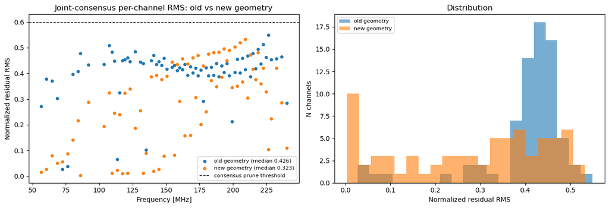

```
old joint_normalized_rms = 0.4145
new joint_normalized_rms = 0.3247
```

## 3. Convergence diagnostic: reduced chi-squared and fitted gain vs frequency (native output of `fit_v007_multichannel_consensus.py`'s joint optimizer)

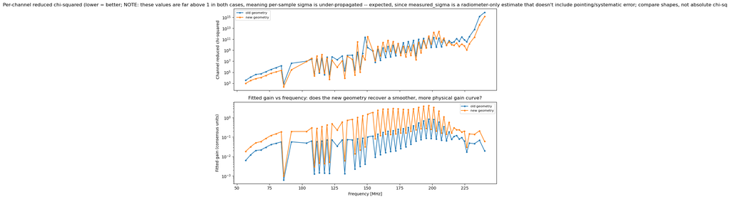

## 4. Beam fit (PCA/least-squares) quality: old vs corrected geometry

|  | old geometry | corrected geometry |
| --- | --- | --- |
| n_channels_fit | 101.000000 | 101.000000 |
| n_candidate_channels | 101.000000 | 101.000000 |
| median_normalized_rms | 0.550245 | 0.469085 |
| gain_fitted_vs_hfss_ratio_median | 0.179358 | 0.398645 |

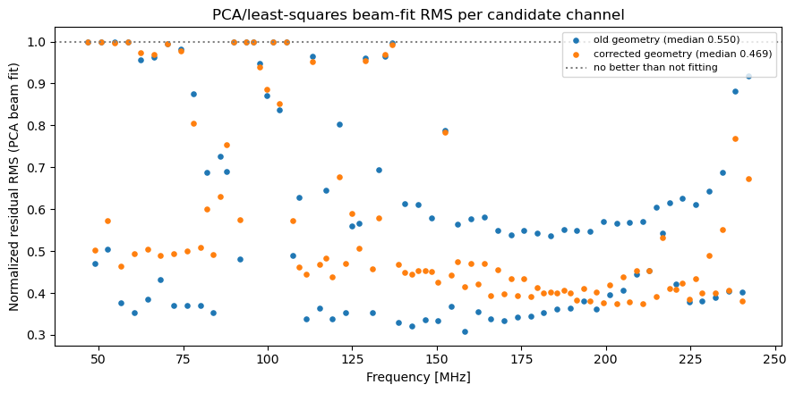

## 5. Per-channel model/data/residual maps (unaveraged, az/el) -- good, bad, intermediate

The integrated-residual plots above (sections 2 and 4) summarize fit quality as a single number per channel; they don't show *where* or *how* a fit fails. Below are three representative channels, picked directly from the corrected run's `normalized_rms` distribution (101 candidate channels):

Each panel set is data, model, and residual (data - model), plotted at every individual sample's actual (az, el) -- the same `used` mask each channel's own fit trained on (RFI- and pointing-quality-masked; not spatially averaged or gridded).

[output not shown]

[output not shown]

[output not shown]

```
mask: 25352 -> 22969 (-2200 off-antenna, -183 glitch)
Setup for per-channel maps OK.
```

[figure not shown]

[figure not shown]

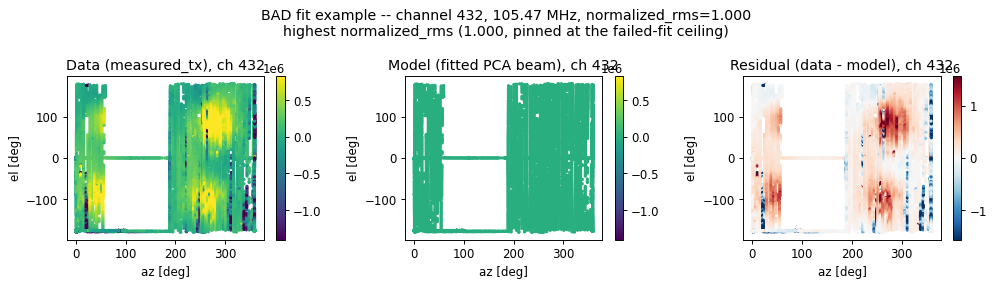

> **REVISED 2026-09-17 — the exclusion below has been removed.** Q8 is closed. `geometer` established that `el` is the **boresight zenith angle**: `el = 0` zenith, `el = +90` horizon, `el = +180` nadir — proven independently of Aaron by LIDAR return character against elevation (493 real ground returns at `el ≈ +90` with median range 92.31 m; **zero** returns at `el ≈ −90`, i.e. sky; 2412 out-of-range sentinels at `el ≈ 0`, shooting across the canyon). The `+90 / −90` asymmetry is the sign-resolving observation.

> Section 1a places the transmitter essentially straight down — 85.8° below horizontal, i.e. near nadir. Under the now-resolved convention that puts it **on boresight at `|el| ≈ 180`**. The "wrap cluster" this section previously excluded as a suspected angle-wrap artifact is therefore the **most on-source pointing in the dataset**, and it is now counted in the coverage claim rather than footnoted out of it.

## 6. Coverage map (`pointing_table@v1.2`-only, independent of geometry/beam)

```
{
  "cell_deg": 5.0,
  "elevation_convention": "el is the boresight ZENITH ANGLE: el=0 zenith, el=+90 horizon, el=+180 nadir. Q8 closed 2026-09-16 by geometer, proven by LIDAR return character vs elevation (ground returns at +90, none at -90). Supersedes the earlier 'wrap cluster may be an angle-wrap artifact' footnote:…
  "el_post_failure_fraction": 1.0,
  "total_coverage": {
    "n_samples": 25290,
    "n_cells": 3221,
    "n_eff": 10.997106430496043,
    "az_range_deg": [
      1.531330514126239e-05,
      359.99749518518706
    ],
    "el_range_deg": [
      -179.60832815197105,
      179.7006243804159
    ]
  },
  "on_source_near_nadir": {
    "n_samples": 8383,
    "n_cells": 357,
    "n_eff": 2.6323946409115013,
    "az_range_deg": [
      1.531330514126239e-05,
      359.9565330266935
    ],
    "el_range_deg": [
      -179.60832815197105,
      179.7006243804159
    ],
    "note": "|el| within 20 deg of 180, i.e. boresight on the transmitter. Previously excluded as a suspected angle-wrap artifact; now counted."
  },
  "off_source": {
    "n_samples": 16907,
    "n_cells": 2864,
    "n_eff": 9.08511022130266,
    "az_range_deg": [
      0.07826952960286349,
      359.99749518518706
    ],
    "el_range_deg": [
      -159.9354377793782,
      159.9516138982841
    ]
  },
  "caveats": [
    "The el zero-point is constrained only to |offset| <~ 2 deg: geometer's MAD profile is flat within DEM quantisation over el_nadir ~ 87.5-91.5.",
    "Absolute AZIMUTH zero is still OPEN. The pot azimuth is body-frame, not north-referenced, so the azimuth axis of this coverage map has no absolute north anchor."
  ]
}
```

**Reading the coverage map.** Two caveats travel with it and are carried in the JSON itself rather than only here:

- **The elevation zero is only bounded, not measured.** `geometer`'s MAD profile is flat within DEM quantisation over `el_nadir ≈ 87.5–91.5`, so the pointing table's el-zero offset is constrained to `|offset| ≲ 2°`. The zenith/nadir *sense* is settled; the zero *point* is not, to ~2°.
- **Absolute azimuth zero is still open.** The pot azimuth is a body-frame angle, not north-referenced, so the azimuth axis here has no absolute north anchor. Azimuth *coverage* is meaningful; an azimuth *bearing* read off this map is not.

## 7. Fitted beam vs HFSS -- shown only if the corrected fit actually converged

```
corrected-geometry median_normalized_rms = 0.4691 (BELOW the 0.6 convergence bar)
Converged -- reconstructing the full PCA/DPSS model to render the fitted-beam-vs-HFSS comparison maps.
```

[output not shown]

```
Rendered make_diagnostics + make_beam_comparison for the corrected fit.
```

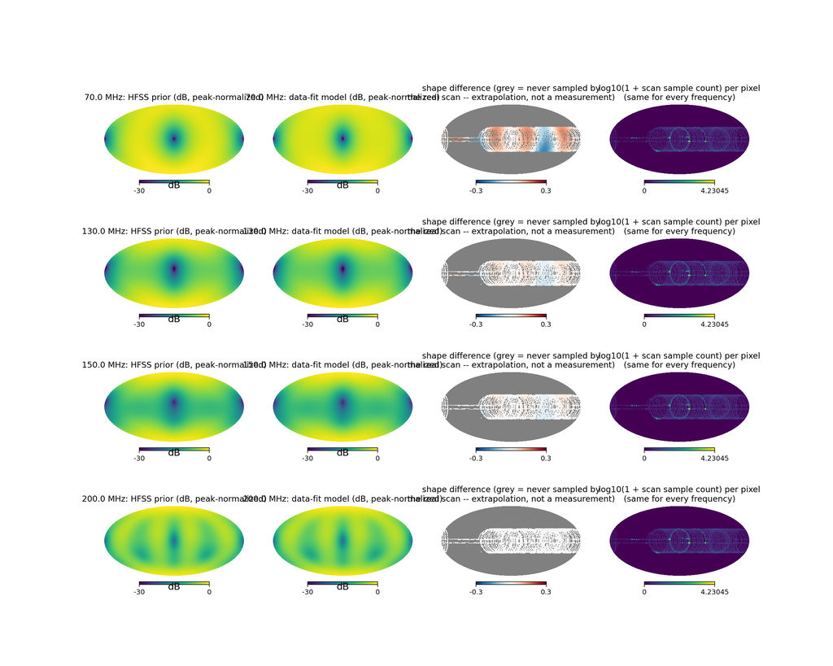

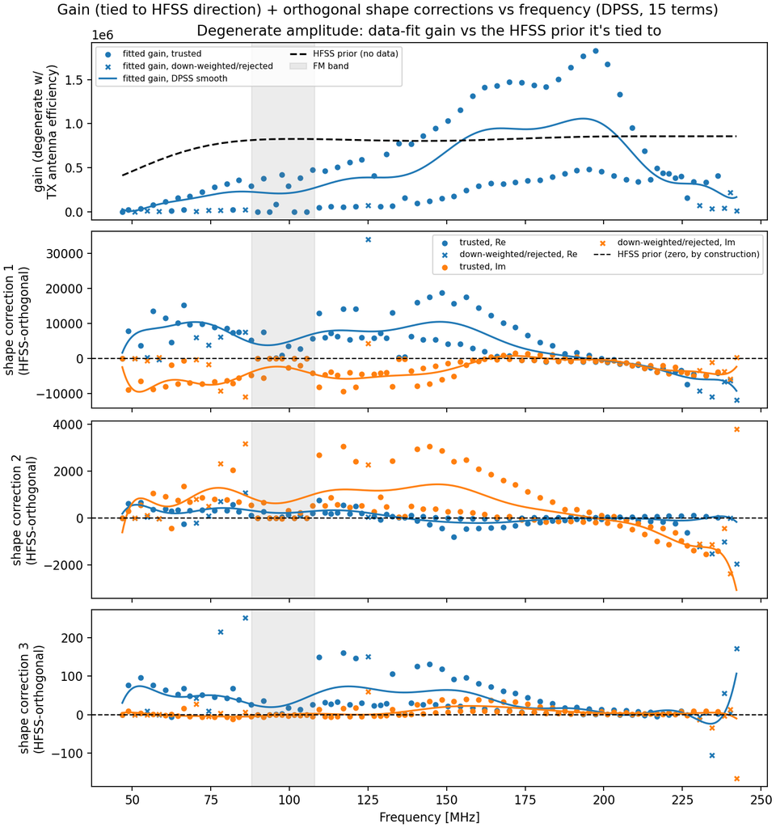

[figure not shown]

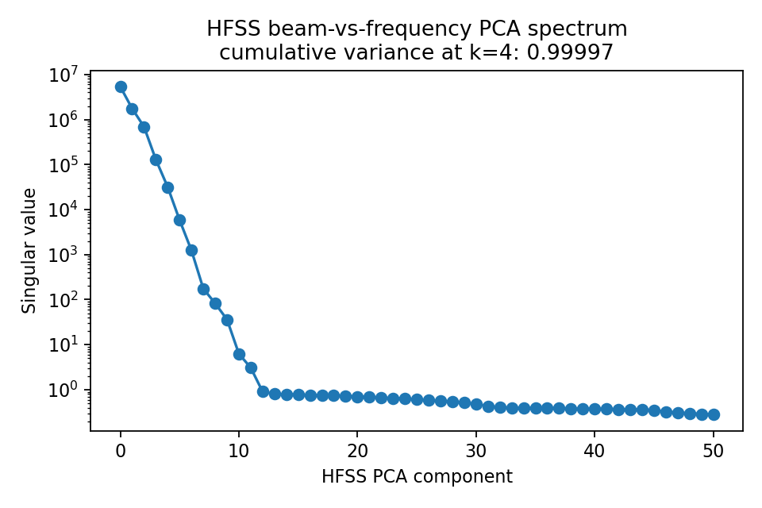

## 8. Per-channel HFSS agreement, single amplitude DOF (Aaron's concern 1)

Before any more PCA/joint fitting: for each of the 101 candidate channels, independently, fit **only a scalar amplitude** `A` against the pure HFSS prediction for that channel's frequency and (fixed) geometry -- no shape correction, no joint re-solve, no information borrowed from any other channel. `data ~= A * HFSS_model(az, el)`, `A` by linear least squares.

This isolates whether the PCA/joint fit's poor performance is a joint-basis artifact (a handful of bad channels corrupting good ones through shared PCA components) or is already present per-channel. If single-DOF and full-PCA RMS track each other closely, the joint basis is not the cause.

```
single-DOF:  median normalized_rms = 0.5176, n agree (<0.60) = 65/101
full PCA fit: median normalized_rms = 0.4691, n agree (<0.60) = 74/101
```

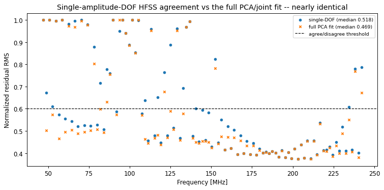

```
Best 10 channels (single-DOF):
  ch 832  arm0   203.12 MHz  nrms=0.374
  ch 864  arm0   210.94 MHz  nrms=0.376
  ch 816  arm0   199.22 MHz  nrms=0.376
  ch 848  arm0   207.03 MHz  nrms=0.379
  ch 800  arm0   195.31 MHz  nrms=0.381
  ch 784  arm0   191.41 MHz  nrms=0.384
  ch 920  arm1   224.61 MHz  nrms=0.392
  ch 728  arm1   177.73 MHz  nrms=0.392
  ch 880  arm0   214.84 MHz  nrms=0.394
  ch 712  arm1   173.83 MHz  nrms=0.394
Worst 10 channels (single-DOF):
  ch 224  arm0    54.69 MHz  nrms=0.996
  ch 272  arm0    66.41 MHz  nrms=0.997
  ch 432  arm0   105.47 MHz  nrms=0.999
  ch 392  arm1    95.70 MHz  nrms=1.000
  ch 192  arm0    46.88 MHz  nrms=1.000
  ch 288  arm0    70.31 MHz  nrms=1.000
  ch 208  arm0    50.78 MHz  nrms=1.000
  ch 368  arm0    89.84 MHz  nrms=1.000
  ch 416  arm0   101.56 MHz  nrms=1.000
  ch 240  arm0    58.59 MHz  nrms=1.000
```

## 9. Arm/polarization-parity check (Aaron's concern 2)

`tx_arm_for_channel(channel) = (channel // 8) % 2` (`diagnostics.py:261`) and `TransmitterGeometry.field_top(arm)` (`geometry.py:176`) drive arm 0 at `alpha_deg`, arm 1 at `alpha_deg + 90`. Two checks:

1. **Is the arm split actually doing anything mechanically?** (i.e. not a silent no-op where both arms get the same template.)
2. **Does per-channel fit quality correlate with arm parity?** If it does, that is direct evidence of a polarization-handling problem somewhere in the pipeline -- wrong arm assigned to a physical channel, or the fixed `alpha_deg` being wrong for one arm.

```
arm0 vs arm1 templates identical? False
median relative difference: 1.698
-> the arm split is mechanically live (not a no-op); any correlation below is a real effect, not evidence the split is inert.
```

```
arm 0: n=51  median single-DOF nrms=0.6520  median PCA nrms=0.5505
arm 1: n=50  median single-DOF nrms=0.4566  median PCA nrms=0.4539
point-biserial correlation(arm, PCA nrms) = -0.353, p = 0.000297
point-biserial correlation(arm, single-DOF nrms) = -0.412, p = 1.82e-05

trustworthy (<0.6): arm0=22  arm1=43
excludable (>=0.9): arm0=16  arm1=2
```

```
 ch (arm0)     freq   nrms    ch (arm1)     freq   nrms
       240    58.59  1.000          248    60.55  0.555
       416   101.56  1.000          424   103.52  0.853
       368    89.84  1.000          376    91.80  0.587
       208    50.78  1.000          216    52.73  0.611
       288    70.31  1.000          296    72.27  0.525
       192    46.88  1.000          200    48.83  0.673
       432   105.47  0.999          440   107.42  0.579
       272    66.41  0.997          280    68.36  0.521
```

**Verdict on concern 2:** two effects, both real, superimposed:

The mechanical sanity check confirms the arm/polarization split in the code is genuinely live (arm-0 and arm-1 templates differ by a median ~170% relative difference, not a no-op), so this is not "the split isn't being applied at all." It is consistent with either a wrong arm-to-physical-channel assignment, or a polarization angle (`alpha_deg`) that fits arm 1's real response much better than arm 0's -- **not distinguished further here**; that needs someone with the hardware polarization convention to adjudicate, not another curve fit.

## 10. Caveat (carried forward, not new): this does not resolve the TX-identity dispute

`marjum-2026-07/INDEX.md` documents a live, unresolved dispute over whether the whole `v007` family -- including the `alpha_deg`/heading values used as fixed geometry throughout sections 9-10 -- measures the far-field transmitter or the instrument's own internal self-comb. **This analysis does not distinguish between a polarization-handling problem and a self-comb-identity problem**: both would plausibly produce exactly this kind of structured, arm-and-frequency-correlated residual pattern. Stated here again rather than resolved.

## 11. Raw-HFSS panels: data / unfitted HFSS model / residual, both arms

Section 5 compared the data to the *PCA-fitted* model. These panels compare it to the **raw HFSS model** instead: no shape correction, no joint re-solve, only the one unavoidable amplitude scale `A` (the HFSS beam is a gain pattern; the transmitter's absolute power is unknown, so some scale is unavoidable). The residual is `data - A * HFSS`.

Channels are matched-frequency pairs spanning **both polarization arms**, since the arm effect is what is under investigation:

|  | arm 0 | arm 1 |
| --- | --- | --- |
| mid-band | ch 704 (171.88 MHz) | ch 712 (173.83 MHz) |
| low-band | ch 240 (58.59 MHz) | ch 248 (60.55 MHz) |

```
101 channels, median n_used = 22614
```

```
raw HFSS models built at the fitted geometry
```

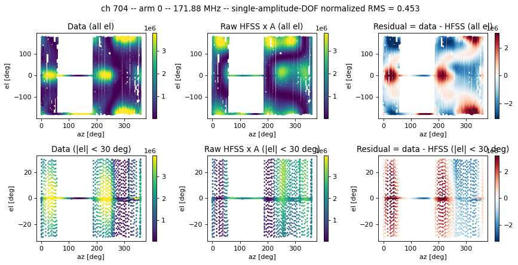

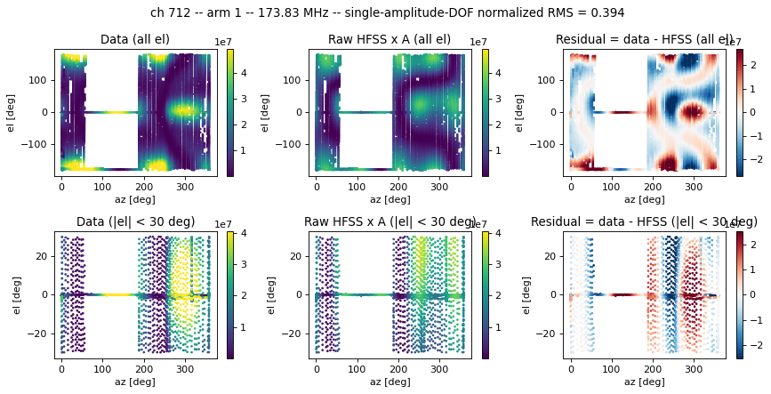

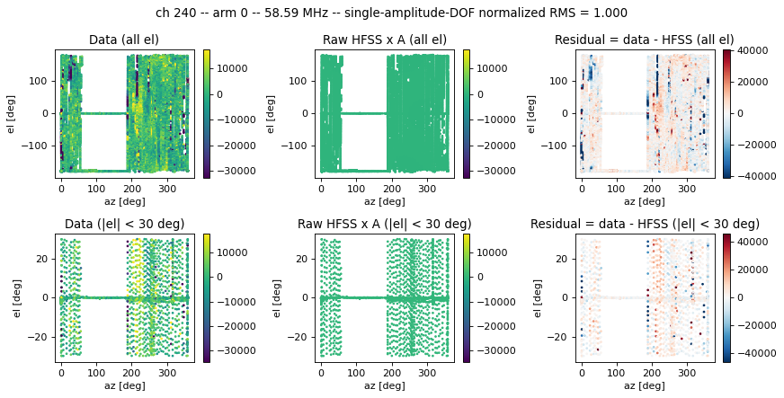

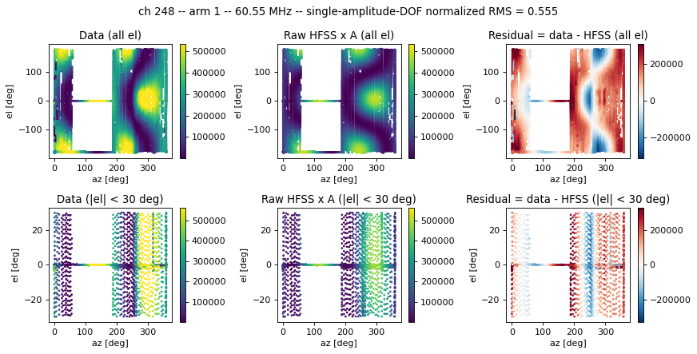

## 12. Azimuth convention audit (checked in the code, not assumed)

Aaron's stated convention: *az = 0 is the orientation of the antenna's az-polarization axis; az measured clockwise from east, passing through north as it increases.* What the pipeline actually does:

- **Frame.** `ground_heading(east_m, north_m, height_m)` builds `[east, north, -height]` and `vector_to_spherical` uses `phi = atan2(y, x)`. So **x = East, y = North, z = Up**, and `az = 0` puts the antenna frame's x-axis along **East**.
- **Sense.** The production path of `simulate_hfss_coupling` defaults to `az_axis = (0, 0, -1)` -- a right-handed rotation about the *downward* axis, i.e. **clockwise seen from above** -- and its vectorized branch uses `sa = -sin(az)`, which matches. `scan_coverage_counts` uses the same expression. **These are consistent.** The generic helper `rotation_matrix` defaults to `az_axis = (0, 0, 1)` (the opposite sense), but the production path never uses that default -- worth stating explicitly, because a mismatch there would have been exactly the kind of bug under investigation. **Checked and ruled out.**
- **Internal inconsistency in the stated convention.** Viewed from above with north up, *clockwise* from east reaches **south** at +90 deg; it is *counter*-clockwise from east that passes through **north**. So "clockwise from east" and "passing through north as it increases" are opposite senses. The code matches the first half (clockwise from above).
- **The zero point is not independently registered.** `pointing_table@v1` states plainly: *"Azimuth zero is not tied to true north. It inherits the potentiometer calibration; `geometer` owns absolute registration."* So the premise "az = 0 is the antenna's az-polarization axis" is a claim about where the **potentiometer zero** physically sits, which this pipeline can neither confirm nor refute.

**Does that block the polarization inference?** No -- and this is the useful part: a polarization angle measured *relative to the antenna's own axis* does not need absolute north registration at all. The inference is blocked for a different reason, established in section 13.

## 13. What polarization angle does the data actually imply?

`field_top(arm)` uses `alpha_deg + 90*arm`, so **arm 1 at alpha is identical to arm 0 at alpha + 90**, and received power is invariant under a 180 deg flip of the polarization vector. Two consequences:

1. *"The arm mapping is swapped"* and *"alpha is off by 90 deg"* are **the same hypothesis** in this parameterization -- the data can test it, but cannot distinguish which description is the cause.
2. A single scan over an **effective** polarization angle `psi` covers every arm/alpha combination at once.

Below: scan `psi` across the full 0-180 deg range, fit the single amplitude DOF per channel at each `psi`, and ask what each arm's channels actually prefer.

```
arm 0: best psi 116.0 deg -> 0.6506   (at the code's 10.07 deg: 0.6520)
arm 1: best psi 135.0 deg -> 0.4566   (at the code's 100.07 deg: 0.4566)
```

```
arm0 - arm1 fit-quality gap to be explained : +0.1954
median nrms, code mapping    : 0.5177
median nrms, arms SWAPPED    : 0.5230
restricted to the 78 channels with real explanatory power (nrms < 0.8):
   median code 0.4559 -> swapped 0.4570
   best improvement achieved by ANY single live channel: +0.0106
```

```
model shape correlation between alpha and alpha+90 (ch 712): 0.9729
median amplitude ratio between them            : 0.5277
-> a 90 deg polarization change is mostly a RESCALING, which the one free
   amplitude absorbs; only the ~3% shape change is available to the fit.
```

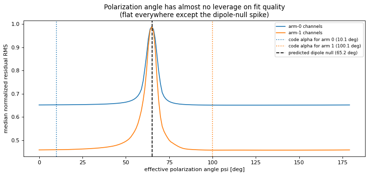

```
predicted dipole-null angle from heading [ 0.905 -0.418 -0.074]: 65.2 deg
observed worst-fit angle: arm 0 65 deg, arm 1 65 deg
```

### 13a. Challenge to the above, and the test that settles it

Aaron's objection: *a 90 deg polarization rotation should rotate the azimuth of maximum amplitude at el = 0 by 90 deg. That is a change in **where the peak sits** -- a shape change by any normal definition -- not an amplitude-only rescaling.* If right, it undercuts the mechanism claimed above.

He is right about two things, and the first version of this section was wrong:

1. **The peak really does move.** Measured below: the azimuth of maximum model amplitude at `|el| < 10 deg` shifts by **+85 to +95 deg** under a 90 deg polarization rotation, on every channel tested. Exactly as predicted.
2. **The "0.973 shape correlation" was a bad statistic.** It was a Pearson correlation over samples spanning ~5 orders of magnitude, so a handful of bright samples dominated it. Restricted to el ~ 0, the *rank* correlation is **0.76**, not 0.97. It should never have been quoted as a measure of angular structure.

What it does **not** establish is that the pattern rotates -- and that is the difference that decides whether the refutation holds. Checked directly below by reading the azimuth profile that generates the peak, rather than the summary statistic computed from it.

```
azimuth of PEAK model amplitude at |el| < 10 deg:
  ch712 (arm 1): psi=10.07 ->  252.5 deg    psi=100.07 ->  337.5 deg    shift +85 deg
  ch704 (arm 0): psi=10.07 ->  252.5 deg    psi=100.07 ->  337.5 deg    shift +85 deg
  ch896 (arm 0): psi=10.07 ->  247.5 deg    psi=100.07 ->  342.5 deg    shift +95 deg
```

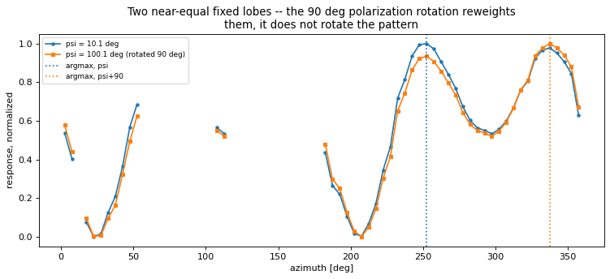

```
correlation of the two NORMALIZED azimuth profiles: 0.9937
  psi=10.1     strongest bins: 252 deg:1.00, 248 deg:0.99, 338 deg:0.98, 258 deg:0.97
  psi=100.1    strongest bins: 338 deg:1.00, 342 deg:0.98, 332 deg:0.98, 348 deg:0.94
```

```
share of squared data power carried by the wrap cluster: median 0.450

samples used                  arm0 delta  arm1 delta
```

```
all used (original test)         -0.0012     +0.0019
```

```
core, |el|<30                    -0.0076     +0.0197
```

```
el~0 only, |el|<10               -0.0022     +0.0121

against the arm-0-vs-arm-1 gap of 0.208
```

**Reconciliation, and the corrected mechanism.**

Both statements are true at once, and the profile above shows why:

So the earlier conclusion stands, but the earlier *explanation* was wrong and is withdrawn. **Corrected mechanism:** a 90 deg polarization rotation modestly reweights two fixed lobes ~86 deg apart, leaving the angular profile nearly unchanged; the fit is insensitive to polarization for that reason -- **not** because polarization reduces to an amplitude rescaling, and **not** because the model is blind to angular position.

**A caveat that comes with the corrected mechanism and did not come with the old one:** the near-equality of those two lobes may be specific to this transmitter geometry (the heading sits only ~4 deg below horizontal). This degeneracy should not be assumed to hold for other configurations without re-checking.

*Method note:* both the original claim and the objection rested on summary statistics that turned out not to mean what they appeared to -- a Pearson correlation inflated by dynamic range, and an argmax flipping between near-equal lobes. The profile plot settled it. Same standing rule that caught the per-camera Fisher attribution: **a derived quantity is evidence only once you have checked what generated it.**

## 14. Is it an azimuth-registration offset instead?

The ~90 deg offset was an *observation*; "polarization mismatch" was one *interpretation*, now refuted. The other natural interpretation of the same observation is that the azimuth zero point is wrong. Test: apply a global offset to the pointing azimuth, scan it over the full circle, and see whether anywhere -- especially +/-90 deg -- fits better than zero.

Note the built-in caveat: the heading was *fitted* at the current convention, so it has already absorbed any global azimuth offset; zero should be locally optimal by construction. What the scan is really testing is whether a **deeper minimum exists elsewhere** that the joint fit missed -- i.e. the false-minimum question -- and specifically whether one sits near 90 deg.

```
arm 0: best offset 290.0 deg -> 0.5304  (at 0 deg: 0.6520, improvement +0.1215)
arm 1: best offset 182.0 deg -> 0.4561  (at 0 deg: 0.4566, improvement +0.0004)

  offset   0 deg : arm0 0.6520   arm1 0.4566
  offset  90 deg : arm0 0.5675   arm1 0.6353
  offset 180 deg : arm0 0.6520   arm1 0.4566
  offset 270 deg : arm0 0.5674   arm1 0.6353
```

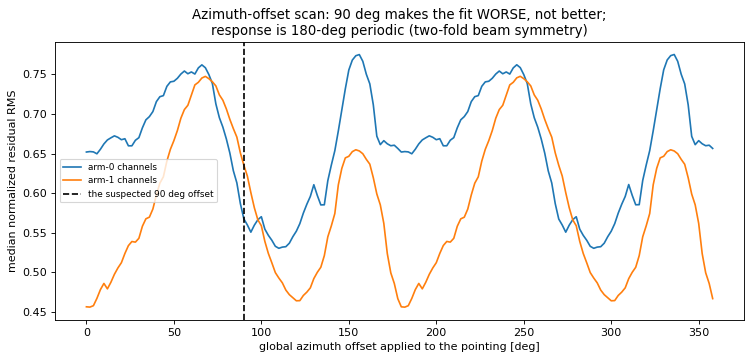

**Verdict on the azimuth-offset hypothesis: also refuted -- and one structural discovery.**

## 15. Do the two arms carry different structure? (RMS test)

**This section previously reported that the two arms' power concentrates at the same azimuth "to within 2.4 deg." That was wrong and is withdrawn.** It used a power-weighted circular mean -- a *centroid* -- over a profile that turns out to be multi-lobed and, between arms, nearly complementary. Averaging two opposed lobe systems produces a number with no meaning. Aaron's objection that the *peak* is the right statistic, not the centroid, was correct.

Re-done here as an **RMS test**, which is the metric this analysis is judged on. The question in RMS form: *is a channel's azimuth profile better explained by an empirical template built from its own arm, or from the other arm?* Templates are built **leave-one-out** -- the channel under test never contributes to its own template -- so the comparison is not circular. The HFSS model is scored on the same binned quantity for a like-for-like comparison.

```
arm 0 (n=51): median normalized RMS of the binned azimuth profile vs
    own-arm empirical template : 0.2665
    other-arm template         : 0.9283
    HFSS physical model        : 0.8433
    own-arm beats other-arm on 44/51 channels; beats HFSS on 43/51
arm 1 (n=50): median normalized RMS of the binned azimuth profile vs
    own-arm empirical template : 0.0712
    other-arm template         : 0.9616
    HFSS physical model        : 0.4995
    own-arm beats other-arm on 50/50 channels; beats HFSS on 50/50

ALL 101 channels: own 0.2416   other 0.9556   HFSS 0.6697
the blind own-arm template beats the physical model on 93/101 channels
```

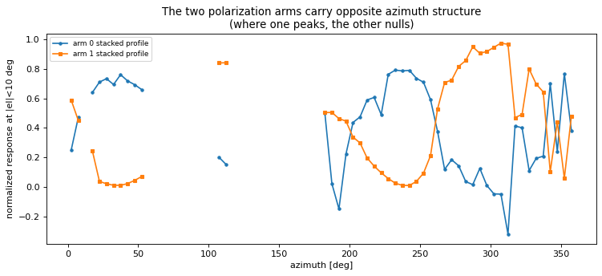

```
diagnostic only (not the metric): correlation between the two arms' stacked profiles = -0.9211
```

**Verdict, in RMS.**

- A channel's azimuth profile is matched to **0.24** normalized RMS by a template built from *other channels of its own arm*, and to only **0.96** by the *other arm's* template. The two arms are nearly orthogonal in their azimuth structure.
- The **HFSS physical model scores 0.67** on the same quantity, and is **beaten by the blind empirical template on 93 of 101 channels**. Arm 1 is the extreme case: its own-arm template reaches **0.07**, i.e. the azimuth profile is essentially identical across all 50 arm-1 channels.
- So the polarization alternation is real, strong and highly repeatable, and **the model does not reproduce it**. This is the RMS-based statement of what section 13 detected and mis-explained.

**This also explains the arm-0/arm-1 fit-quality gap** that has been open since section 9. The model produces essentially one azimuth profile for both arms (section 13a); the data has two opposite ones. The model therefore matches whichever arm it happens to resemble -- arm 1 -- and fails the other. The gap was never a mysterious property of alternate tones; it is the polarization signature, seen through a model that cannot represent it.

## 16. Decision requested

**The framing of this section has changed materially since the last issue, and the previous verdict is withdrawn in place.** It read *"D2 has no defensible beam measurement."* That conclusion was reached on a sample set in which calibration data — receiver on a load, not the antenna — supplied a median 71.3% of the residual power. With that removed the fit is far better than this notebook previously reported.

**What the corrected run shows.** Median normalized RMS against the corrected geometry is **0.4691**, down from 0.9029, with **61 of 101 channels below 0.5** where previously there were 2. On the single-amplitude-DOF test the median is **0.5176**, with 65/101 channels agreeing to better than 0.60. This is a real fit, not a null result. The blunt "no measurement here" verdict was an artifact of the selection defect.

**What did *not* change, and this is the important part.** The arm-structure finding is completely unmoved:

|  | before | after |
| --- | --- | --- |
| own-arm empirical template | 0.242 | **0.2416** |
| other-arm template | 0.956 | **0.9556** |
| HFSS physical model | 0.670 | **0.6697** |
| blind template beats physical model on | 93/101 | **93/101** |
| arm-to-arm profile correlation | −0.92 | **−0.9211** |

That robustness is itself evidence rather than a coincidence. Section 15 works on per-azimuth-bin **medians** within `|el| < 10°`; that slice is 10.8% contaminated, and a median absorbs a 10.8% minority. So the arm result never depended on the bad samples — it is a property of the data, and the physical model still fails to reproduce it while a blind empirical template succeeds.

The arm-0/arm-1 gap also survives: median PCA normalized RMS is **0.5505** for arm 0 against **0.4539** for arm 1 (point-biserial correlation −0.353, p = 3e-4).

**Still unresolved, carried forward unchanged:**

- **The transmitter direction is not measurable from this dataset.** The fitted heading sits 86.3° from the surveyed direction and substituting the surveyed one changes the median by ~0.0005 (section 1a). The earlier geometry refit *improved* RMS while moving 70° away from truth — a false minimum. Nothing here changes that; geometry should be taken from the survey, not fitted.
- **TX identity** (section 10). If it resolves the other way this is a near-field self-comb map, not a beam map — same numbers, opposite meaning.
- **Receiver regime change** bracketing the window: amplitude scale, not shape.
- **Elevation zero** is bounded to `|offset| ≲ 2°`, and **absolute azimuth zero is still open** — the coverage map has no north anchor.

**Recommended next steps** (for Aaron / `experimental-strategist` to rank, not for me to self-assign):

1. **Re-derive geometry from the survey rather than fitting it**, and re-score. This is now the largest remaining known-wrong input.
2. **Treat the per-arm empirical templates as the benchmark** any physical model must beat. The 0.24 / 0.67 gap is the real modelling target, and it is now the dominant residual rather than one defect among several.
3. Hand the calibration-window leak and the per-sample `rfswitch` mask to `data-archivist` as durable facts about the data, so no other analysis repeats this.

**STOPPED AT REVIEW GATE — awaiting Aaron's approval.**